# Begin Graphing in RStudio Open Ended Assignment

Robert T Kohn

9/9/25

# Exploring Categorical Data

```r
require(ggmosaic)
data(fly)
head(fly)
```

```
## # A tibble: 6 × 27
##           id flight_freq          do_you_recline      height  has_child_under_18
##        <dbl> <fct>                <fct>               <fct>   <fct>
## 1 3436139758 once a year or less  <NA>                 <NA>   <NA>
## 2 3434278696 once a year or less  about half the time "6'3\"" yes
## 3 3434275578 once a year or less  usually             "5'8\"" no
## 4 3434268208 once a year or less  always              "5'11\… no
## 5 3434250245 once a month or less about half the time "5'7\"" no
## 6 3434245875 once a year or less  usually             "5'9\"" yes
## # ℹ 22 more variables: three_seats_two_arms <fct>, two_seats_one_arm <fct>,
## #   window_shade <fct>, rude_to_move_to_unsold_seat <fct>,
## #   rude_to_talk_to_neighbor <fct>, six_hr_flight_leave_seat <fct>,
## #   reclining_obligation_to_behind <fct>, rude_to_recline <fct>,
## #   eliminate_reclining <fct>, rude_to_switch_seats_friends <fct>,
## #   rude_to_switch_seats_family <fct>, rude_to_wake_neighbor_bathroom <fct>,
## #   rude_to_wake_neighbor_walk <fct>, rude_to_bring_baby <fct>, …
```

```r
fly=na.omit(fly)
```

# Planning the exploration

I wish to explore the relationship between how often someone travels by plane(flight_freq) and if they have a child under 18(has_child_under_18)

I want the has_child_under_18 to be on the x axis with flight_freq as the y.

# Bar Charts

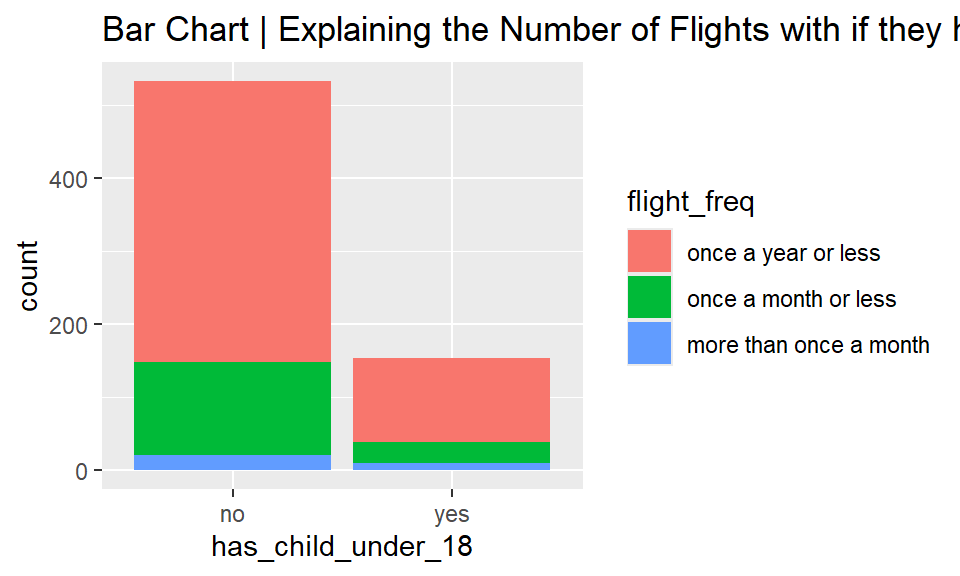

```r
gf_bar( ~ has_child_under_18 , data = fly , fill = ~ flight_freq, title="Bar Chart | Explaining the Number of Flights with if they have a minor")
```

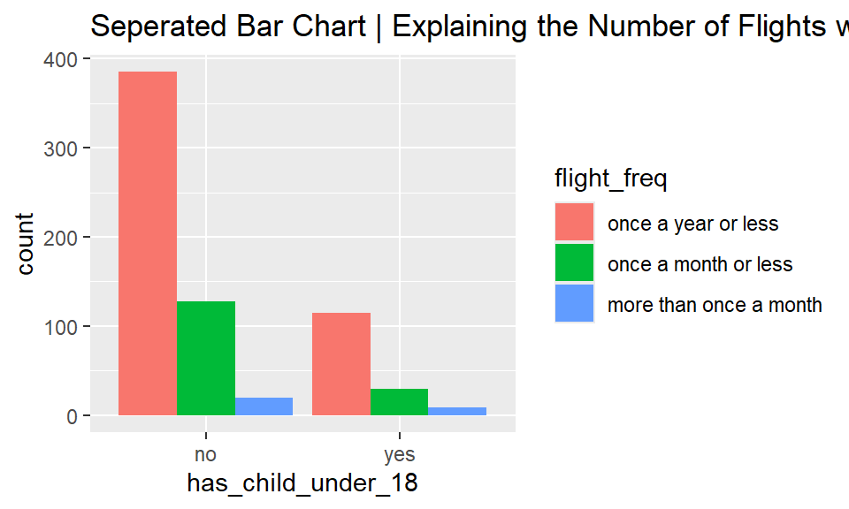

```r
gf_bar( ~ has_child_under_18 , data = fly , fill = ~ flight_freq,position = position_dodge( ), title="Seperated Bar Chart | Explaining the Number of Flights with if they have a minor" )
```

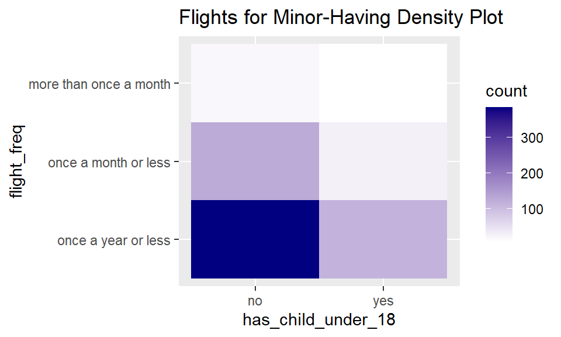

```r
gf_bin2d(flight_freq~has_child_under_18, data=fly, title="Flights for Minor-Having Density Plot") %>%
gf_refine(scale_fill_continuous(low = "white", high = "navy"))
```

# Breaking it Down

For both those who have a child under 18 and those who don’t, there seems to be a very similar trend in terms of how often they fly. There’s a lot flying a year or less and then a slow decrease for then on.

I liked the side by side comparison bar chart best as it demonstrated a clear trend and doesn’t look as messy.

There isn’t anything particular I would change, I am sure if I used the density bar chart it would show the trend more clearly though.

# Exploring 1 Categorical & 1 Numeric Variable

```r
require(Stat2Data)
data(Election08)
head(Election08)
```

```
##         State Abr Income   HS   BA Dem.Rep ObamaWin
## 1    Alabama   AL  32404 80.4 21.4      -1        0
## 2     Alaska   AK  40352 90.5 26.0     -11        0
## 3    Arizona   AZ  33029 83.5 25.3       0        0
## 4   Arkansas   AR  30060 81.1 19.3      12        0
## 5 California   CA  41571 80.2 29.5      19        1
## 6   Colorado   CO  41042 88.9 35.0      11        1
```

```r
Election08$Winner <- ifelse(Election08$ObamaWin == 1, "Obama", "McCain")
```

The question I will be exploring is “Did having higher per capita income in the state as of 2007(Income) have an impact over whether Obama won the state(ObamaWin)?”

I anticipate that there will be a connection between these two variables as Obama pushed for more social programs which impact the way taxes were used and often benefited the lower class.

On the y axis, I will put ObamaWin and on the x axis I will put Income.

# Y and X Graphs

```r
require(ggforce)
```

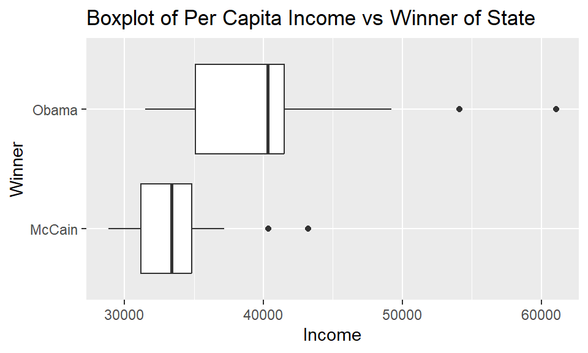

```r
gf_boxplot( Winner ~ Income , data = Election08 , options,title="Boxplot of Per Capita Income vs Winner of State")
```

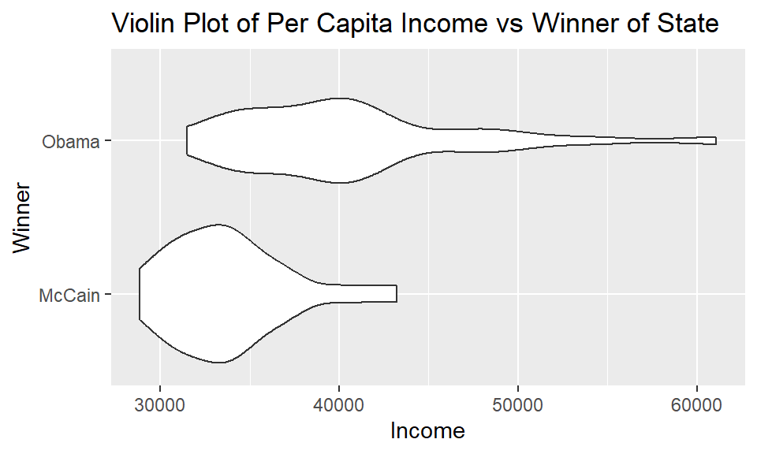

```r
gf_violin( Winner ~ Income , data = Election08 ,title="Violin Plot of Per Capita Income vs Winner of State")
```

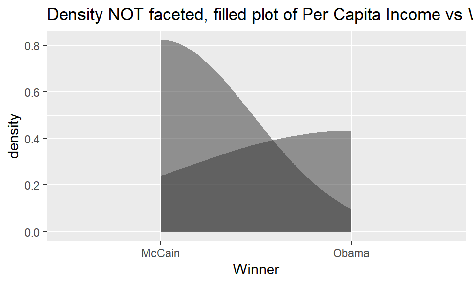

```r
gf_density( ~ Winner , data = Election08 , fill = ~ Income , alpha = 0.5,title="Density NOT faceted, filled plot of Per Capita Income vs Winner of State")
```

When looking at the graphs, there is a relatively clear pattern in the graphs but it was not what I quite expected. Obama’s states typically had a greater income even in the bottom end where the minimum would be. Additionally, I like the violin plot as it illustrates the density around each income amount and you see that McCain is very popular in low income states and Obama has support from the few higher end without requiring understanding of a boxplot. I wish I had the colors on the density not faceted plot because it would be a neat graphic on a report but not much else.

# 2 Numeric Variables

```r
data(AccordPrice)
head(AccordPrice)
```

```
##   Age Price Mileage
## 1   7  12.0    74.9
## 2   4  17.9    53.0
## 3   4  15.7    79.1
## 4   7  12.5    50.1
## 5   9   9.5    62.0
## 6   1  21.5     4.8
```

# Exploring Data

I am interested in exploring the relationship between price and mileage. More specifically if there seems to be a trend between how many miles a Honda Accord has and its price. The second one drives a car off the lot its signficiantly cheaper for the next person to buy, however, what is the impact of mileage?

I will be exploring Mileage as my X and Price as the Y.

# Application

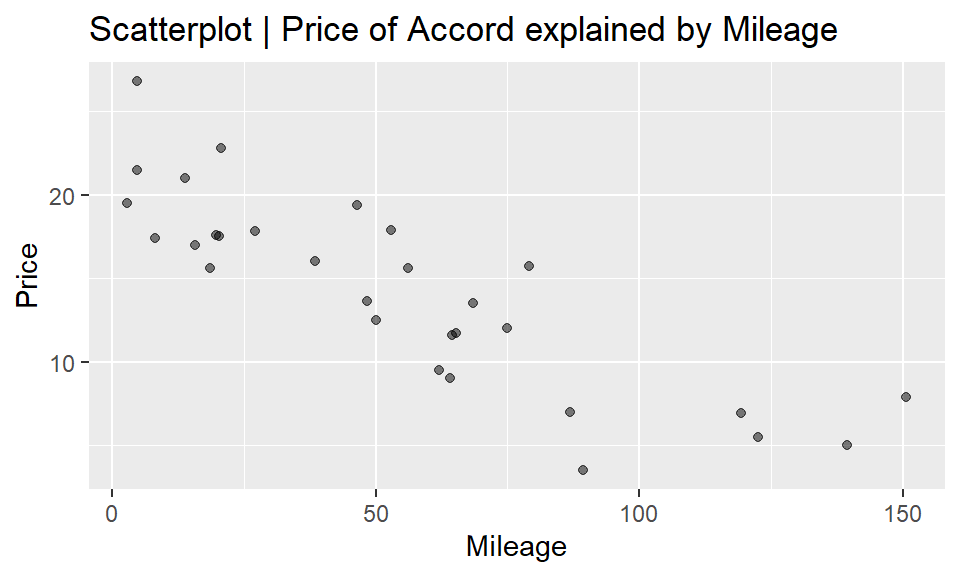

```r
gf_point( Price ~ Mileage , data = AccordPrice, alpha = 0.5 , title="Scatterplot | Price of Accord explained by Mileage")
```

# Contour Lines & Layers

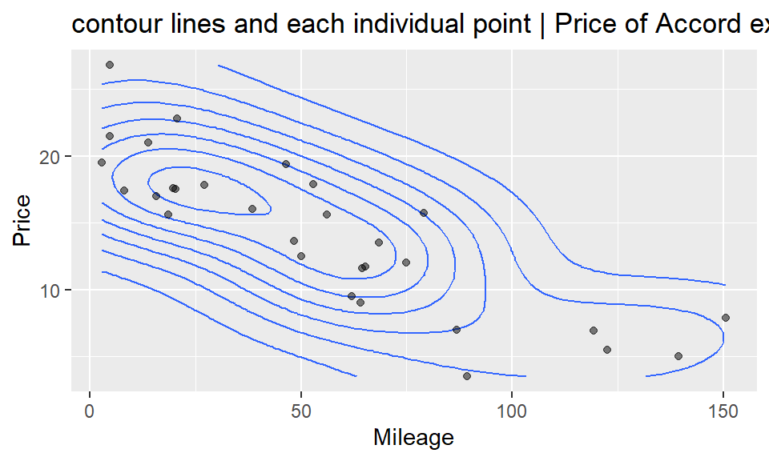

```r
gf_density_2d( Price ~ Mileage , data = AccordPrice, title="contour lines and each individual point | Price of Accord explained by Mileage") %>% gf_point(Price ~ Mileage , data = AccordPrice , alpha = 0.5 )
```

# Density Filled (With Layers)

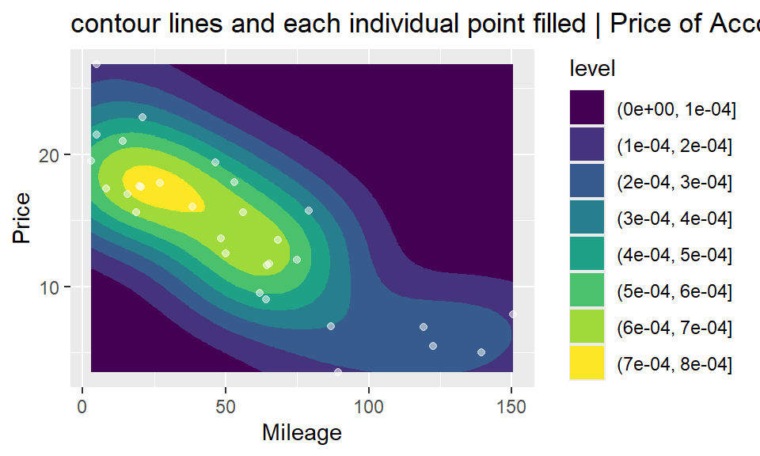

```r
gf_density_2d_filled( Price ~ Mileage , data = AccordPrice, title="contour lines and each individual point filled | Price of Accord explained by Mileage") %>% gf_point(Price ~ Mileage , data = AccordPrice , alpha = 0.5, color="white")
```

It stands to reason that as a car has a greater mileage it will decrease in price. I wonder what is happening with the point which has >0 miles but the highest price. I believe the contour lined plot with individual points is best because it showcases the range and points. I dont have any major changes.